# Clasificación

Las técnicas de aprendizaje automático *supervisado* implican entrenar un modelo para operar en un conjunto de *características* y predecir una *etiqueta* utilizando un conjunto de datos que incluye algunos valores de etiqueta ya conocidos. Puede pensar en esta función de esta manera, en la que *y* representa la etiqueta que queremos predecir y *X* representa el vector de características que usa el modelo para predecirlo.

$$y = f([x_1, x_2, x_3, ...])$$

*Clasificación* es una forma de aprendizaje automático supervisado en el que entrena un modelo para usar las características (los valores *x* en nuestra función) para predecir una etiqueta (*y*) que calcula el probabilidad de que el caso observado pertenezca a cada una de varias clases posibles, y prediga una etiqueta apropiada. La forma más simple de clasificación es la clasificación *binaria*, en la que la etiqueta es 0 o 1, que representa una de dos clases; por ejemplo, "Verdadero" o "Falso"; "Interno o externo"; "rentable" o "no rentable"; y así.

## Clasificación binaria

En este cuaderno, nos centraremos en un ejemplo de *clasificación binaria*, donde el modelo debe predecir una etiqueta que pertenece a una de dos clases. En este ejercicio, entrenaremos un clasificador binario para predecir si un paciente debe o no someterse a una prueba de diabetes en función de algunos datos médicos.

### Explorar los datos

> **Cita**: El conjunto de datos de diabetes utilizado en este ejercicio se basa en datos recopilados originalmente por el Instituto Nacional de Diabetes y Enfermedades Digestivas y Renales.

```python
import pandas as pd
import wget

# load the training dataset
wget.download('https://raw.githubusercontent.com/MicrosoftDocs/mslearn-introduction-to-machine-learning/main/Data/ml-basics/diabetes.csv')
diabetes = pd.read_csv('diabetes.csv')
diabetes.head()
```

```
100% [............................................................................] 776415 / 776415
```

|  | PatientID | Pregnancies | PlasmaGlucose | DiastolicBloodPressure | TricepsThickness | SerumInsulin | BMI | DiabetesPedigree | Age | Diabetic |
| --- | --- | --- | --- | --- | --- | --- | --- | --- | --- | --- |
| 0 | 1354778 | 0 | 171 | 80 | 34 | 23 | 43.509726 | 1.213191 | 21 | 0 |
| 1 | 1147438 | 8 | 92 | 93 | 47 | 36 | 21.240576 | 0.158365 | 23 | 0 |
| 2 | 1640031 | 7 | 115 | 47 | 52 | 35 | 41.511523 | 0.079019 | 23 | 0 |
| 3 | 1883350 | 9 | 103 | 78 | 25 | 304 | 29.582192 | 1.282870 | 43 | 1 |
| 4 | 1424119 | 1 | 85 | 59 | 27 | 35 | 42.604536 | 0.549542 | 22 | 0 |

Estos datos consisten en información de diagnóstico sobre algunos pacientes a los que se les ha realizado la prueba de diabetes. Desplácese hacia la derecha si es necesario y tenga en cuenta que la columna final en el conjunto de datos (**Diabetic**) contiene el valor *0* para pacientes que dieron negativo en la prueba de diabetes y *1* para pacientes que dieron positivo. Esta es la etiqueta que entrenaremos para que prediga nuestro modelo; la mayoría de las demás columnas (**Embarazos**, **Glucosa plasmática**, **Presión arterial diastólica**, etc.) son las funciones que usaremos para predecir la etiqueta **Diabético**.

Separemos las características de las etiquetas: llamaremos a las características *X* y a la etiqueta *y*:

```python
# Separate features and labels
features = ['Pregnancies','PlasmaGlucose','DiastolicBloodPressure','TricepsThickness','SerumInsulin','BMI','DiabetesPedigree','Age']
label = 'Diabetic'
X, y = diabetes[features].values, diabetes[label].values

for n in range(0,4):
    print("Patient", str(n+1), "\n  Features:",list(X[n]), "\n  Label:", y[n])
```

```
Patient 1
  Features: [0.0, 171.0, 80.0, 34.0, 23.0, 43.50972593, 1.213191354, 21.0]
  Label: 0
Patient 2
  Features: [8.0, 92.0, 93.0, 47.0, 36.0, 21.24057571, 0.158364981, 23.0]
  Label: 0
Patient 3
  Features: [7.0, 115.0, 47.0, 52.0, 35.0, 41.51152348, 0.079018568, 23.0]
  Label: 0
Patient 4
  Features: [9.0, 103.0, 78.0, 25.0, 304.0, 29.58219193, 1.282869847, 43.0]
  Label: 1
```

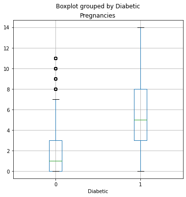

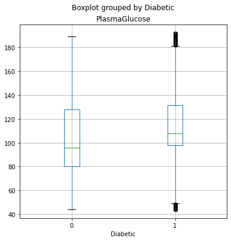

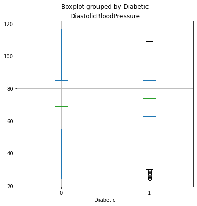

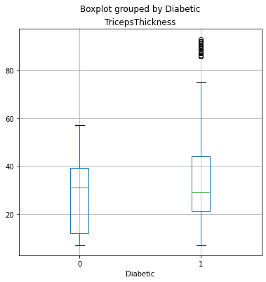

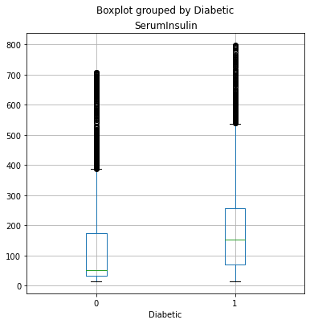

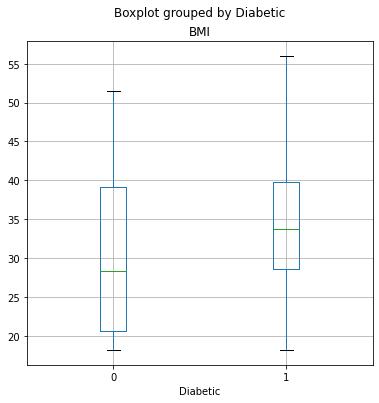

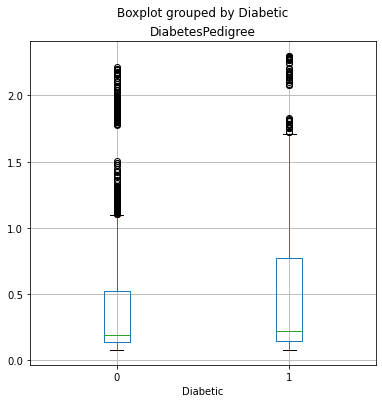

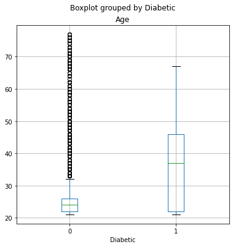

```python
from matplotlib import pyplot as plt
%matplotlib inline

features = ['Pregnancies','PlasmaGlucose','DiastolicBloodPressure','TricepsThickness','SerumInsulin','BMI','DiabetesPedigree','Age']
for col in features:
    diabetes.boxplot(column=col, by='Diabetic', figsize=(6,6))
    plt.title(col)
plt.show()
```

Para algunas de las características, hay una diferencia notable en la distribución de cada valor de etiqueta. En particular, **Embarazos** y **Edad** muestran distribuciones marcadamente diferentes para pacientes diabéticos que para pacientes no diabéticos. Estas características pueden ayudar a predecir si un paciente es diabético o no.

### Dividir los datos

Nuestro conjunto de datos incluye valores conocidos para la etiqueta, por lo que podemos usarlo para entrenar un clasificador para que encuentre una relación estadística entre las características y el valor de la etiqueta; pero ¿cómo sabremos si nuestro modelo es bueno? ¿Cómo sabemos que predecirá correctamente cuando lo usamos con nuevos datos con los que no fue entrenado? Bueno, podemos aprovechar el hecho de que tenemos un gran conjunto de datos con valores de etiqueta conocidos, usar solo una parte para entrenar el modelo y retener algunos para probar el modelo entrenado, lo que nos permite comparar las etiquetas pronosticadas con las ya conocidas. etiquetas en el conjunto de prueba.

En Python, el paquete **scikit-learn** contiene una gran cantidad de funciones que podemos usar para crear un modelo de aprendizaje automático, incluida una función **train_test_split** que garantiza que obtengamos una división estadísticamente aleatoria de los datos de entrenamiento y prueba. Usaremos eso para dividir los datos en un 70 % para el entrenamiento y retener un 30 % para las pruebas.

```python
from sklearn.model_selection import train_test_split

# Split data 70%-30% into training set and test set
X_train, X_test, y_train, y_test = train_test_split(X, y, test_size=0.30, random_state=0)

print ('Training cases: %d\nTest cases: %d' % (X_train.shape[0], X_test.shape[0]))
```

```
Training cases: 10500
Test cases: 4500
```

### Entrenar y evaluar un modelo de clasificación binaria

Bien, ahora estamos listos para entrenar nuestro modelo ajustando las funciones de entrenamiento (**X_train**) a las etiquetas de entrenamiento (**y_train**). Hay varios algoritmos que podemos usar para entrenar el modelo. En este ejemplo, usaremos *Regresión logística*, que (a pesar de su nombre) es un algoritmo bien establecido para la clasificación. Además de las características y etiquetas de entrenamiento, necesitaremos establecer un parámetro de *regularización*. Esto se usa para contrarrestar cualquier sesgo en la muestra y ayudar a que el modelo se generalice bien evitando *sobreajustar* el modelo a los datos de entrenamiento.

> **Nota**: Los parámetros para los algoritmos de aprendizaje automático generalmente se denominan *hiperparámetros* (para un científico de datos, los *parámetros* son valores en los propios datos - ¡los *hiperparámetros* se definen externamente a partir de los datos!)

```python
# Train the model
from sklearn.linear_model import LogisticRegression

# Set regularization rate
reg = 0.01

# train a logistic regression model on the training set
model = LogisticRegression(C=1/reg, solver="liblinear").fit(X_train, y_train)
print (model)
```

```
LogisticRegression(C=100.0, solver='liblinear')
```

Ahora que hemos entrenado el modelo usando los datos de entrenamiento, podemos usar los datos de prueba que retuvimos para evaluar qué tan bien predice. Nuevamente, scikit-learn puede ayudarnos a hacer esto. Comencemos usando el modelo para predecir etiquetas para nuestro conjunto de prueba y comparemos las etiquetas pronosticadas con las etiquetas conocidas:

```python
predictions = model.predict(X_test)
print('Predicted labels: ', predictions)
print('Actual labels:    ' ,y_test)
```

```
Predicted labels:  [0 0 0 ... 0 1 0]
Actual labels:     [0 0 1 ... 1 1 1]
```

The arrays of labels are too long to be displayed in the notebook output, so we can only compare a few values. Even if we printed out all of the predicted and actual labels, there are too many of them to make this a sensible way to evaluate the model. Fortunately, **scikit-learn** has a few more tricks up its sleeve, and it provides some metrics that we can use to evaluate the model.

The most obvious thing you might want to do is to check the *accuracy* of the predictions - in simple terms, what proportion of the labels did the model predict correctly?

```python
from sklearn.metrics import accuracy_score

print('Accuracy: ', accuracy_score(y_test, predictions))
```

```
Accuracy:  0.7891111111111111
```

La precisión se devuelve como un valor decimal: un valor de 1,0 significaría que el modelo acertó en el 100 % de las predicciones; mientras que una precisión de 0.0 es, bueno, ¡bastante inútil!

## Resumen

Aquí preparamos nuestros datos dividiéndolos en conjuntos de datos de prueba y entrenamiento, y aplicamos la regresión logística, una forma de aplicar etiquetas binarias a nuestros datos. Nuestro modelo fue capaz de predecir si los pacientes tenían diabetes con lo que parece ser una precisión razonable. ¿Pero es esto lo suficientemente bueno? En el próximo cuaderno, veremos alternativas a la precisión que pueden ser mucho más útiles en el aprendizaje automático.

```python
from sklearn. metrics import classification_report

print(classification_report(y_test, predictions))
```

```
              precision    recall  f1-score   support

           0       0.81      0.88      0.85      2986
           1       0.72      0.60      0.66      1514

    accuracy                           0.79      4500
   macro avg       0.77      0.74      0.75      4500
weighted avg       0.78      0.79      0.78      4500
```

El informe de clasificación incluye las siguientes métricas para cada clase (0 y 1)

> tenga en cuenta que es posible que la fila del encabezado no coincida con los valores.
- *Precisión*: De las predicciones que hizo el modelo para esta clase, ¿qué proporción fueron correctas?
- *Recuerde*: De todas las instancias de esta clase en el conjunto de datos de prueba, ¿cuántas identificó el modelo?
- *F1-Score*: una métrica promedio que tiene en cuenta tanto la precisión como la recuperación.
- *Soporte*: ¿Cuántas instancias de esta clase hay en el conjunto de datos de prueba?

El informe de clasificación también incluye promedios para estas métricas, incluido un promedio ponderado que permite el desequilibrio en la cantidad de casos de cada clase.

Debido a que este es un problema de clasificación *binario*, la clase *1* se considera *positiva* y su precisión y recuperación son particularmente interesantes; en efecto, responden las preguntas:

- De todos los pacientes que el modelo predijo que son diabéticos, ¿cuántos son realmente diabéticos?
- De todos los pacientes que en realidad son diabéticos, ¿cuántos identificó el modelo?

Puede recuperar estos valores por sí solos usando las métricas **precision_score** y **recall_score** en scikit-learn (que por defecto asumen un modelo de clasificación binaria).

```python
from sklearn.metrics import precision_score, recall_score

print("Overall Precision:",precision_score(y_test, predictions))
print("Overall Recall:",recall_score(y_test, predictions))
```

```
Overall Precision: 0.723673792557403
Overall Recall: 0.6036988110964333
```

Las métricas de precisión y recuperación se derivan de cuatro posibles resultados de predicción:

- *Verdaderos positivos*: la etiqueta pronosticada y la etiqueta real son ambas 1.
- *Falsos positivos*: la etiqueta predicha es 1, pero la etiqueta real es 0.
- *Falsos negativos*: la etiqueta predicha es 0, pero la etiqueta real es 1.
- *Negativos verdaderos*: la etiqueta pronosticada y la etiqueta real son ambas 0.

Estas métricas generalmente se tabulan para el conjunto de prueba y se muestran juntas como una *matriz de confusión*, que toma la siguiente forma:

| TN | FP |
| --- | --- |
| FN | TP |